# INFSCI 2595 Final Project

Part 2C, Regression - Model Predictions

Zhenyu Li

2022-04-15

```r
library(tidyverse)
theme_set(theme_linedraw())
library(bayesplot)
source("./scripts/utils.R")
```

```r
df <- readr::read_csv("./data/final_project_train.csv", col_names = TRUE)
df_preproc <- df %>%
  mutate_if(is.character,as.factor) %>%
  select(-c(rowid,outcome)) %>%
  mutate(
    response = log(response),
    across(starts_with("x"), scale)
  )
my_inputs <- setdiff(names(df_preproc),"response")
```

In this section, I will visualize how selected predictors (inputs) could predict the `response` using the linear models created earlier.

## Preparation

### Model Selection

**Select two Bayesian models from 2B for prediction and visualization.**

- Choose two with similar posterior σ but different features:
- One with `region` interacting inputs with non-linear basis (2 dof natural spline) `mod_2B3_2Ac3`.
  - This is the best model identified using WAIC during Bayesian model fitting.
- One with only linear additive inputs `mod_2B1_2A3`.
  - This is the best model identified by BIC in MLE model fitting.

```r
mod_2A3 <- readr::read_rds("models/mod_2A3")
mod_2Ac3 <- readr::read_rds("models/mod_2Ac3")
mod_2B1_2A3 <- readr::read_rds("models/mod_2B1_2A3")
mod_2B3_2Ac3 <- readr::read_rds("models/mod_2B3_2Ac3")
```

### Input Selection

**Select inputs to visualize, based on model coefficient significance.**

**First model, plot significant coefficients.**

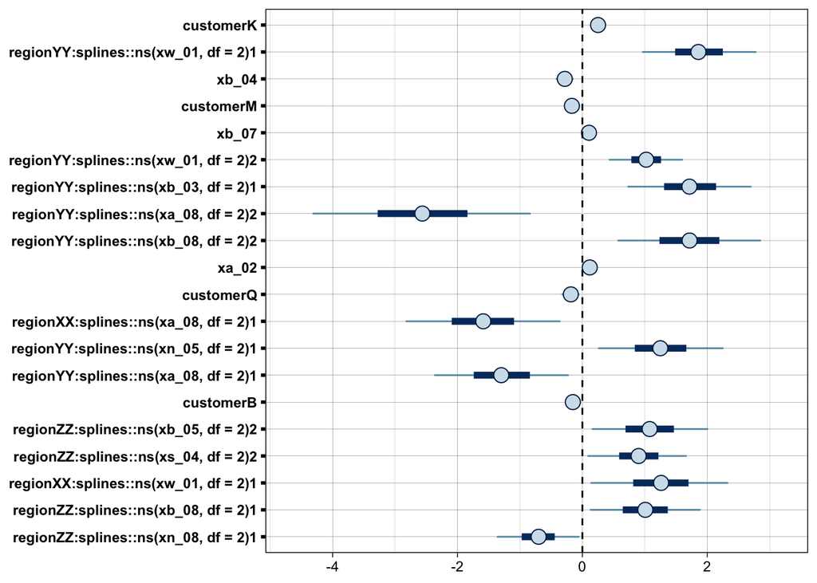

```r
mod_2B3_2Ac3 %>% as_tibble() %>%
  select(all_of(
    mod_2Ac3 %>% pull_lm_coefs_signif(top_n = 20) %>% select(coef) %>% unlist(use.names=F)
  )) %>%
  # mcmc_areas_ridges(prob=0.6, prob_outer = 0.9) +
  mcmc_intervals() +
  geom_vline(xintercept = 0,linetype="dashed")
```

- Among these significant coefficients:
  - The linear inputs have much less magnitudes and uncertainties.
  - Interaction between `region` to non-linear features have greater uncertainty, but also greater magnitudes.

**Second model, plot significant coefficients.**

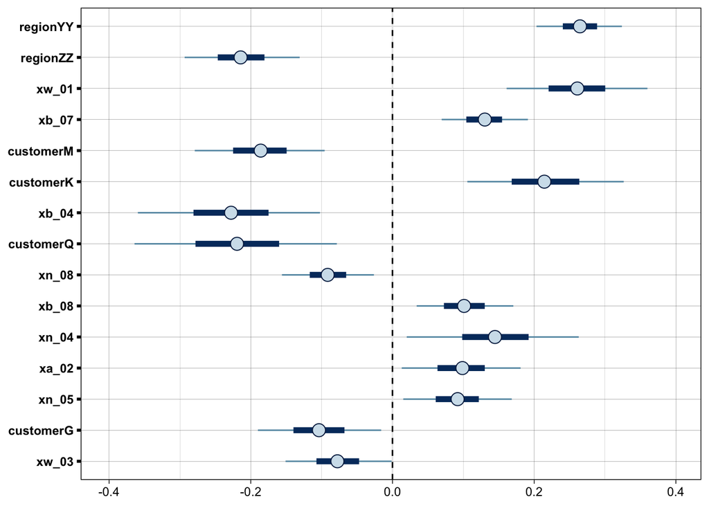

```r
mod_2B1_2A3 %>% as_tibble() %>%
  select(all_of(
    mod_2A3 %>% pull_lm_coefs_signif(top_n = 15) %>% select(coef) %>% unlist(use.names=F)
  )) %>%
  # mcmc_areas_ridges(prob=0.6, prob_outer = 0.9) +
  mcmc_intervals() +
  geom_vline(xintercept = 0,linetype="dashed")
```

- All linear feature coefficients are quite small compared to the nonlinear predictors from first model `mod_2B3_2Ac3`.

**Choose predictors to use based on both models.**

## Predictions

### Set 1: xb_07, xb_04

This set of inputs is associated with the top 2 ranked continuous inputs.

```r
viz_grid <- make_test_input_grid(my_inputs, df_preproc, c("xb_07", "xb_04"))
```

**First model**

[output not shown]

[output not shown]

[output not shown]

[output not shown]

[output not shown]

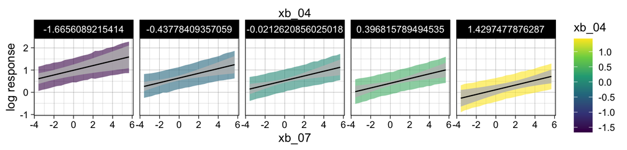

```r
make_post_pred(mod_2B3_2Ac3, viz_grid) %>% ggplot(aes(x=xb_07, fill=xb_04)) +
  geom_ribbon(aes(ymin = y_lwr, ymax = y_upr), alpha=0.6) +
  geom_ribbon(aes(ymin = trend_lwr, ymax = trend_upr), alpha=0.8, fill="grey") +
  geom_line(aes(y = trend_avg), size=0.5) +
  facet_grid(~xb_04, scales="free_y") +
  scale_x_continuous(sec.axis = sec_axis(~ . , name = "xb_04", breaks = NULL, labels = NULL)) +
  scale_fill_viridis_c() + ylab("log response")
```

- The log-response increases with the linear predictor `xb_07` (each facet).
- The log-response decreases with the linear predictor `xb_04` (horizontal facts, shift trends down).
- There is higher uncertainty on the model behavior (mean trend) when inputs are at extreme values.

**Second model**

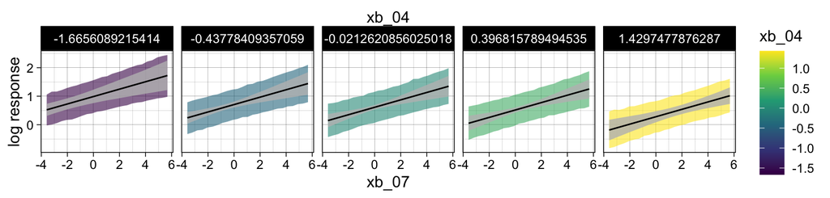

```r
viz_grid <- make_test_input_grid(my_inputs, df_preproc, c("xb_07", "xb_04"))

make_post_pred(mod_2B1_2A3, viz_grid) %>% ggplot(aes(x=xb_07, fill=xb_04)) +
  geom_ribbon(aes(ymin = y_lwr, ymax = y_upr), alpha=0.6) +
  geom_ribbon(aes(ymin = trend_lwr, ymax = trend_upr), alpha=0.8, fill="grey") +
  geom_line(aes(y = trend_avg), size=0.5) +
  facet_grid(~xb_04, scales="free_y") +
  scale_x_continuous(sec.axis = sec_axis(~ . , name = "xb_04", breaks = NULL, labels = NULL)) +
  scale_fill_viridis_c() + ylab("log response")
```

- Same trends as with the first model.

### Set 2: xb_07, customer

This set of inputs are selected to examine how the categorical input `customer` affects the ability for the top ranked continuous input to predict.

```r
viz_grid <- make_test_input_grid(my_inputs, df_preproc, c("xb_07"), "customer")
```

**First model**

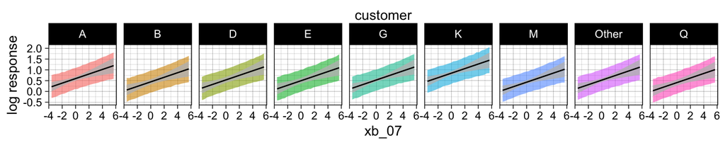

```r
make_post_pred(mod_2B3_2Ac3, viz_grid) %>%
  ggplot(aes(x=xb_07, fill=customer)) +
  geom_ribbon(aes(ymin = y_lwr, ymax = y_upr), alpha=0.6) +
  geom_ribbon(aes(ymin = trend_lwr, ymax = trend_upr), alpha=0.8, fill="grey") +
  geom_line(aes(y = trend_avg), size=0.5) +
  facet_grid(~customer) +
  scale_x_continuous(sec.axis = sec_axis(~ . , name = "customer", breaks = NULL, labels = NULL)) +
  ylab("log response") + theme(legend.position="none")
```

- The `customer` input affects how the linear predictor `xb_07` predicts the log-response.
  - Customers `A`,`K` tend to have higher response.
  - Customers `M`,`Q` tend to have lower response.

**Second model**

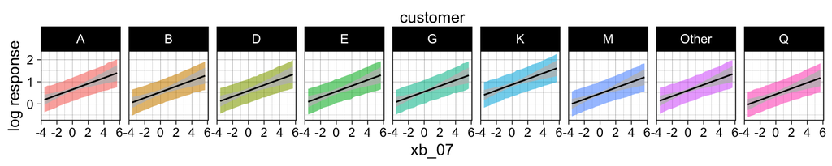

```r
make_post_pred(mod_2B1_2A3, viz_grid) %>%
  ggplot(aes(x=xb_07, fill=customer)) +
  geom_ribbon(aes(ymin = y_lwr, ymax = y_upr), alpha=0.6) +
  geom_ribbon(aes(ymin = trend_lwr, ymax = trend_upr), alpha=0.8, fill="grey") +
  geom_line(aes(y = trend_avg), size=0.5) +
  facet_grid(~customer) +
  scale_x_continuous(sec.axis = sec_axis(~ . , name = "customer", breaks = NULL, labels = NULL)) +
  ylab("log response") + theme(legend.position="none")
```

- Same trends as with the first model.

### Set 3: xa_08, xb_07, region

This set of inputs involves the most important linear continuous input (`xb_07`), and the nonlinear continuous input with most magnitude (`xa_08`). I hope to visualize how the two inputs affect the response, at different `region` categories.

```r
viz_grid <- make_test_input_grid(my_inputs, df_preproc, c("xa_08", "xb_07"), "region")
```

**First model**

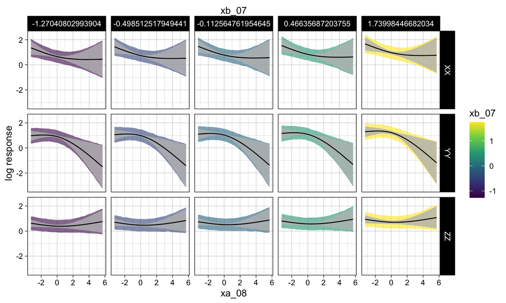

```r
make_post_pred(mod_2B3_2Ac3, viz_grid) %>%
  ggplot(aes(x=xa_08, fill=xb_07)) +
  geom_ribbon(aes(ymin = y_lwr, ymax = y_upr), alpha=0.6) +
  geom_ribbon(aes(ymin = trend_lwr, ymax = trend_upr), alpha=0.8, fill="grey") +
  geom_line(aes(y = trend_avg), size=0.5) +
  facet_grid(region~xb_07) +
  scale_x_continuous(sec.axis = sec_axis(~ . , name = "xb_07", breaks = NULL, labels = NULL)) +
  scale_fill_viridis_c() + ylab("log response")
```

- Effect of nonlinear predictor `xa_08` depends on the `region`:
  - In region `XX`, high `xa_08` slightly decreases the log-response;
  - In region `YY`, high `xa_08` greatly decreases the log-response;
  - This input does not have much effect for region `ZZ`.
- The nonlinear predictors from `xa_08` have large model uncertainties (mean behavior), especially at extreme predictor values.
  - This may suggest overfit when the inputs are at extremes.
- Increasing the linear predictor `xb_07` slightly increase the response (horizontal facets).
  - The magnitude of the effect is overshadowed by the nonlinear predictor (the coefficients are small).

**Second model**

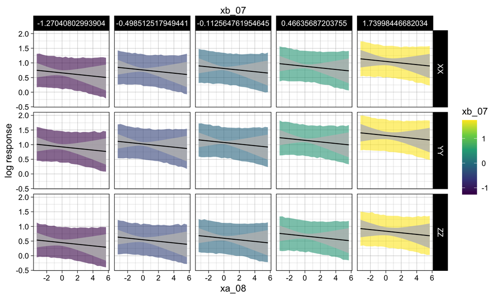

```r
make_post_pred(mod_2B1_2A3, viz_grid) %>%
  ggplot(aes(x=xa_08, fill=xb_07)) +
  geom_ribbon(aes(ymin = y_lwr, ymax = y_upr), alpha=0.6) +
  geom_ribbon(aes(ymin = trend_lwr, ymax = trend_upr), alpha=0.8, fill="grey") +
  geom_line(aes(y = trend_avg), size=0.5) +
  facet_grid(region~xb_07) +
  scale_x_continuous(sec.axis = sec_axis(~ . , name = "xb_07", breaks = NULL, labels = NULL)) +
  scale_fill_viridis_c() + ylab("log response")
```

- Compared to the first model with `region` interacting with nonlinear features, this linear additive only model is less flexible and unable to adapt to the trend based on `region` because there is no interaction.
  - All we get is that different `region` shifts the trends up and down.
- This resulted higher prediction uncertainty but relatively smaller model uncertainty as compared to the other model.

### Set 4: xw_01, xb_03, region

This is just another set of inputs similar to set 3. Here I selected the input associated with the top ranked nonlinear features (`xw_01`).

```r
viz_grid <- make_test_input_grid(my_inputs, df_preproc, c("xw_01", "xb_03"), "region")
```

**First model**

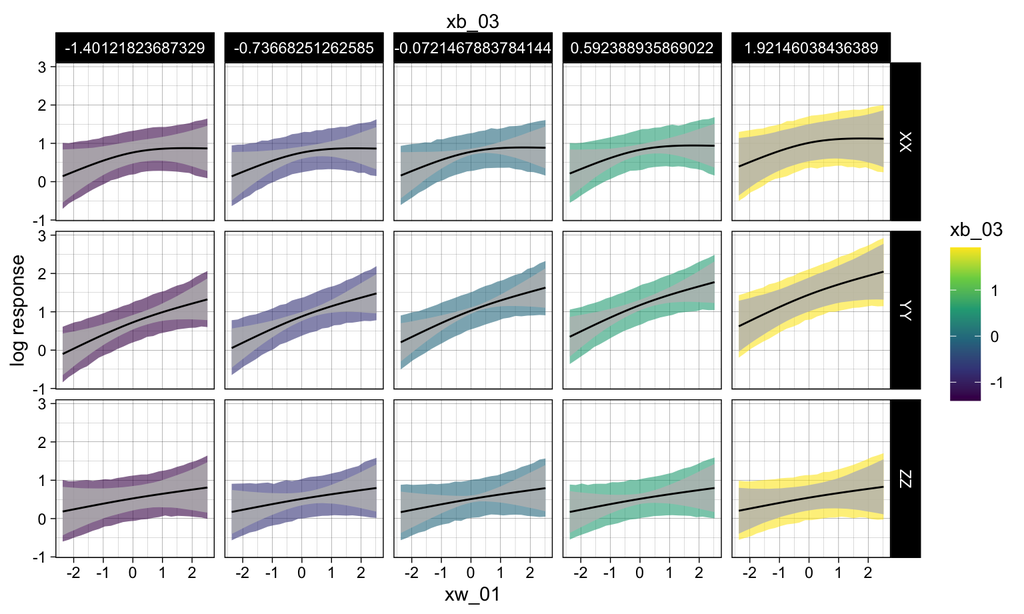

```r
make_post_pred(mod_2B3_2Ac3, viz_grid) %>%
  ggplot(aes(x=xw_01, fill=xb_03)) +
  geom_ribbon(aes(ymin = y_lwr, ymax = y_upr), alpha=0.6) +
  geom_ribbon(aes(ymin = trend_lwr, ymax = trend_upr), alpha=0.8, fill="grey") +
  geom_line(aes(y = trend_avg), size=0.5) +
  facet_grid(region~xb_03) +
  scale_x_continuous(sec.axis = sec_axis(~ . , name = "xb_03", breaks = NULL, labels = NULL)) +
  scale_fill_viridis_c() + ylab("log response")
```

- Increasing nonlinear predictor `xw_01` has increase response, but the scale is different across regions.
- The nonlinear predictor `xb_03` increases response for regions `XX`,`YY` but not in `ZZ`.

**Second model**

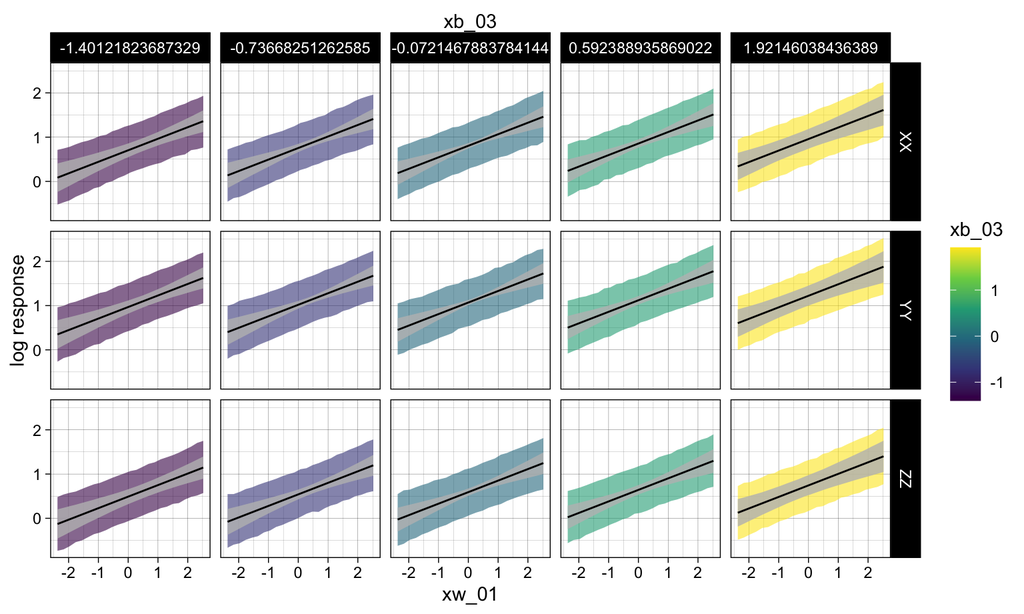

```r
make_post_pred(mod_2B1_2A3, viz_grid) %>%
  ggplot(aes(x=xw_01, fill=xb_03)) +
  geom_ribbon(aes(ymin = y_lwr, ymax = y_upr), alpha=0.6) +
  geom_ribbon(aes(ymin = trend_lwr, ymax = trend_upr), alpha=0.8, fill="grey") +
  geom_line(aes(y = trend_avg), size=0.5) +
  facet_grid(region~xb_03) +
  scale_x_continuous(sec.axis = sec_axis(~ . , name = "xb_03", breaks = NULL, labels = NULL)) +
  scale_fill_viridis_c() + ylab("log response")
```

- We see similar effect as with the prior comparisons, that the linear inputs only model is unable to fit more closely to observations in the specific region category.

## Conclusions

- For the inputs that are visualized, whether predictive trends are consistent across the two models depends on what we examine.
- The trends from simple additive linear predictors and categorical predictors are almost identical.
- For inputs that involve interaction:
  - The model with interaction from `region` to continuous inputs is more capable of explaining the observed variation per `region` category, as compared to the model with no interaction.
  - But this may cause higher risk of overfitting, when the observations are rare: in our data, when the inputs are at extreme values.